# Colombia

Institutional Module

The Community Trust Index (CTI) assesses the level of trust in the Colombian Red Cross Society, focusing on community perceptions of its actions, competencies, values, and engagement with affected populations. The study was conducted between July and September 2025 across 31 departments of Colombia in the context of the country’s migration response. The survey aimed to measure trust in the Colombian Red Cross and identify the factors that shape confidence in its ability to deliver relevant, effective, and accountable humanitarian assistance. The findings provide evidence to strengthen community relationships, improve programme delivery, and support decision-making in migration-related operations.

**Summary**

# Sampling

The survey was conducted between July and September 2025 across Colombia, covering 31 departments nationwide, with the exception of Bogotá Capital District and Vaupés. A total of 888 respondents participated in the study.

A stratified random sampling approach was used to ensure representation across key population groups, including differences in age, gender, education level, and geographic location. Data collection was carried out by Colombian Red Cross volunteers to assess community trust in the context of the migration response and to better understand perceptions of the organization’s performance and engagement with communities.

## Geographic

The survey sample differs from the population distribution across Colombia’s departments, indicating that the geographic composition of the sample is not fully representative of the national population. Amazonas accounts for 0.5% of survey respondents compared with 15.8% of the population, making it substantially underrepresented in the sample. Similarly, Norte de Santander represents 3.3% of respondents versus 10.8% of the population, while San Andrés y Providencia accounts for 1.7% of respondents compared with 4.6% of the population. These differences reflect the survey’s geographic coverage and sampling design across the 31 participating departments.

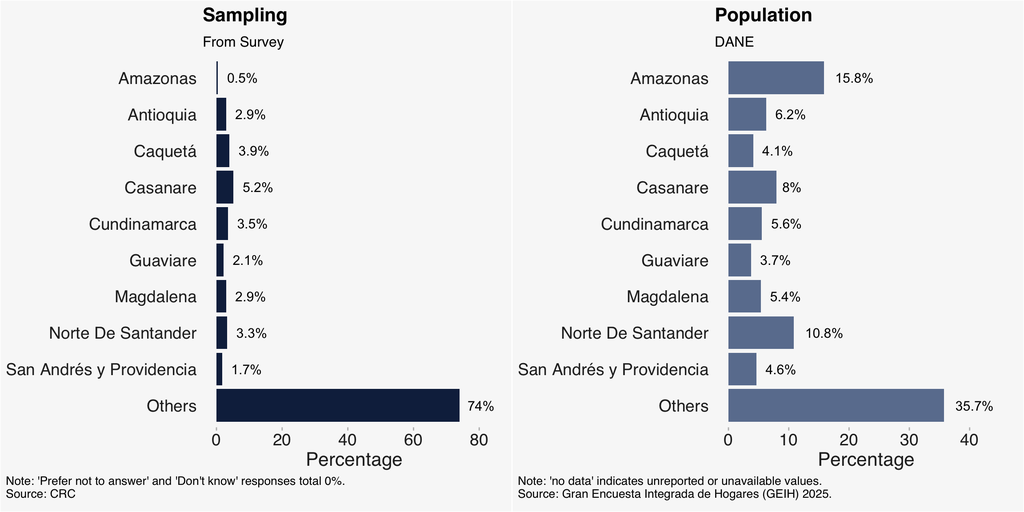

## Coverage

## Gender and Age

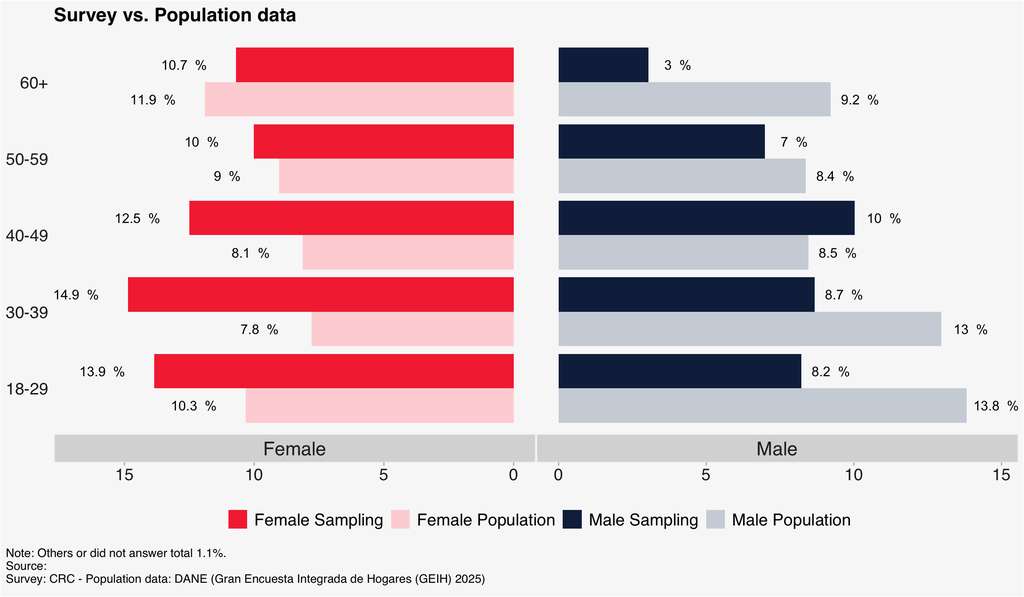

## Education

The educational profile of the survey sample differs substantially from that of the national population. Respondents with tertiary education account for 59.7% of the sample compared with 26.4% of the population, while individuals with no formal education represent only 1.1% of respondents versus 42.9% of the population. This indicates a strong overrepresentation of more highly educated individuals in the survey. Although these differences are notable, education will not be included in the post-stratification process due to limitations in the available population data and the risk of generating unstable weights.

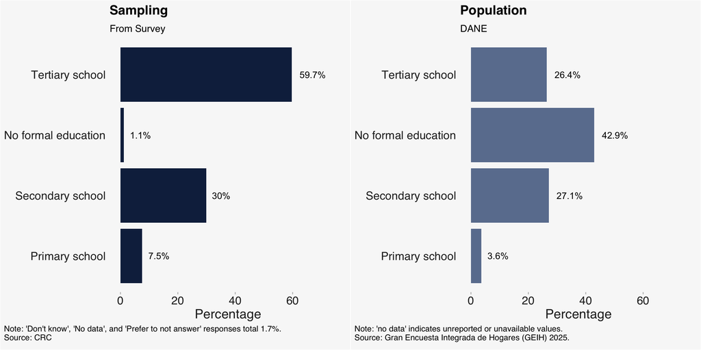

## Ethnical Group

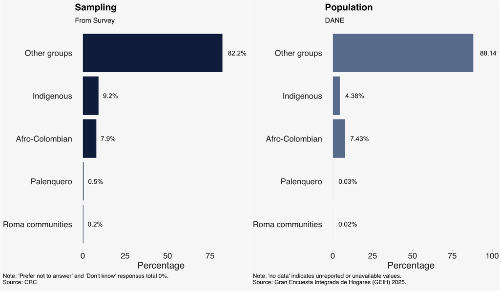

## Limitations

The findings should be interpreted with several limitations in mind. Although the survey achieved broad geographic coverage across 31 departments, Bogotá Capital District and Vaupés were not included. As a result, the findings are more representative of Colombia outside the Capital District than of the country as a whole.

The sample also differed from the national population profile, particularly with regard to education levels. Post-stratification weighting was applied to improve representativeness by age and gender; however, sample sizes within individual departments were not sufficient to support robust geographic weighting. Consequently, departmental comparisons should be interpreted with caution, and the results are best understood as reflecting overall national patterns rather than precise estimates for specific departments.

# Survey Results

The charts below present the survey answers as percentages, offering visualization of the Community Trust levels by subdimensions. They illustrate the distribution of community’s perceptions of the competencies and values.

## Perception of trust

### Competencies

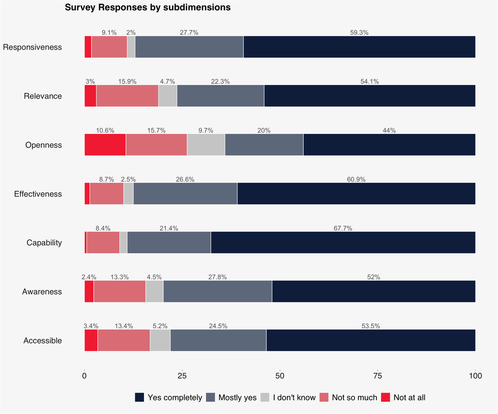

### Values

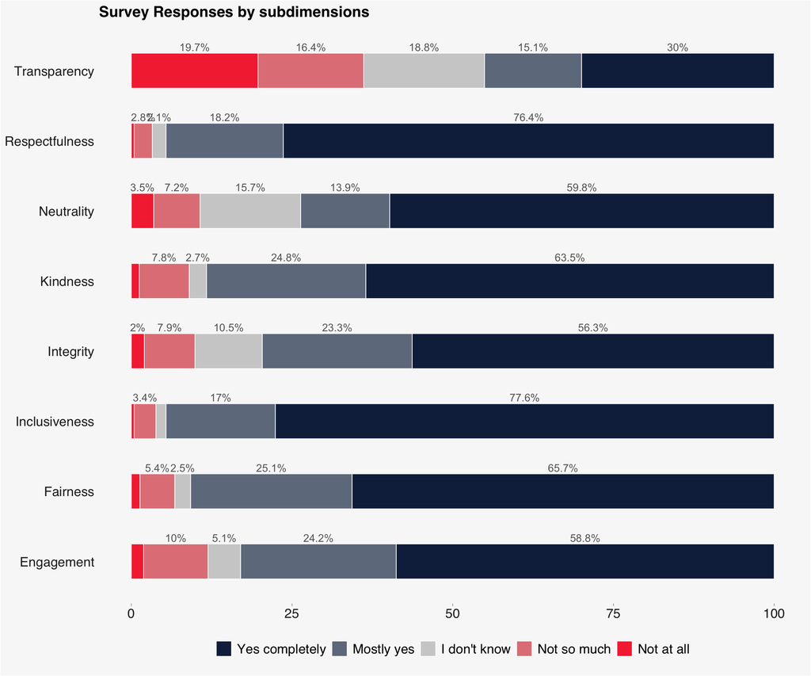

### Additional Questions

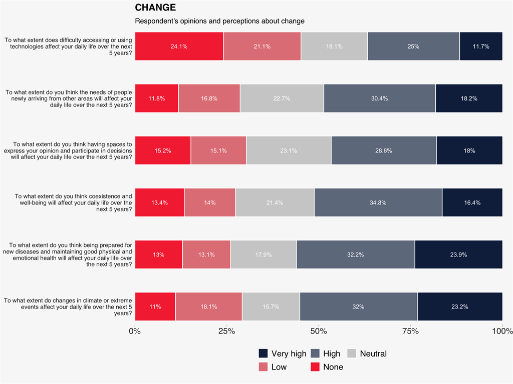

## Contextual questions

The findings show substantial engagement with the Colombian Red Cross. Two-thirds of respondents have received support from the organization, while around four in ten have volunteered or made a donation. Blood donation is less common but still reported by more than one-third of respondents.

### Experiences

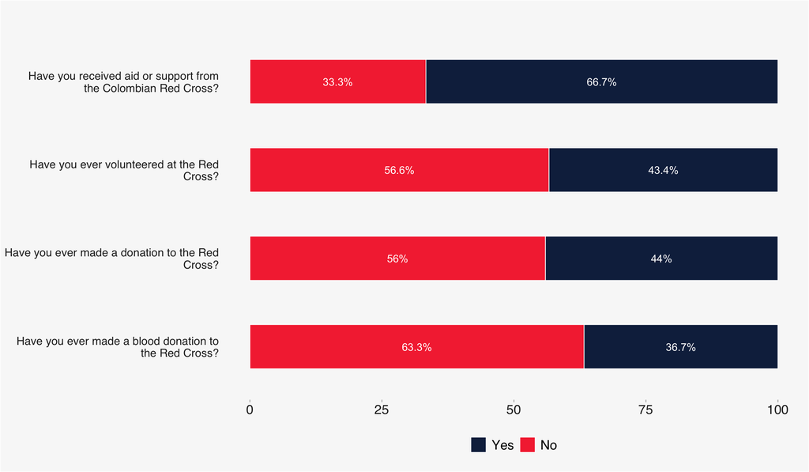

### Behaviours

The findings suggest that many respondents have had prior interactions with the Colombian Red Cross. A majority report having requested support from the organization and are aware of mechanisms for providing feedback, complaints, or suggestions. Experience with the Red Cross is even more widespread when it comes to recommending its services and following its advice during crises.

- **Strong endorsement:** Around 85% of respondents have recommended the Red Cross to people in need.
- **Trusted guidance:** A similar proportion (85%) report having followed Red Cross advice during a crisis.
- **Broad service reach:** Six in ten respondents have previously requested support from the Red Cross.
- **Awareness of feedback channels:** About 61% know how to submit feedback, complaints, or requests to the organization.

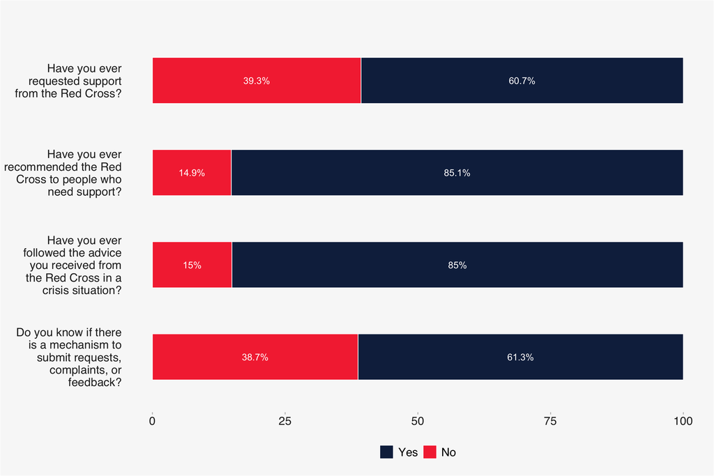

### Intention

The findings indicate a strong willingness to engage with the Colombian Red Cross. Respondents are particularly likely to follow Red Cross advice during crises and recommend the organization to others, reflecting high levels of trust and confidence. Most also express willingness to request support, volunteer, donate, or donate blood.

- **High confidence in Red Cross advice:** Nearly all respondents would follow Red Cross guidance during a crisis.
- **Strong advocacy:** More than nine in ten would recommend the Red Cross to people in need.
- **Willingness to engage:** Around two-thirds are likely to volunteer, donate, or donate blood.
- **Confidence in services:** More than four in five would seek support from the Red Cross if needed.

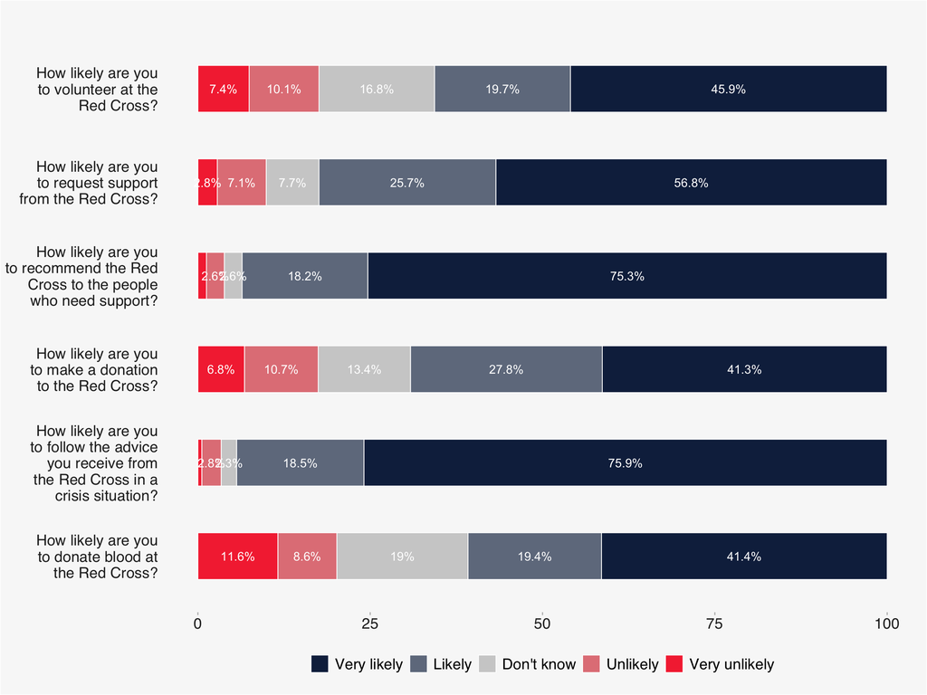

# Score

This score is derived from responses to questions that assess perceptions of competencies and values, providing a comprehensive measure of trust. A higher score indicates stronger trust, suggesting that community members believe their needs are being addressed and their values are respected. *Learn more about scoring method: Methods*

## Overall Score

The results show strong perceptions of both the Colombian Red Cross’ competencies (7.93) and values (8.18).

- Among the **competencies**, Capability (8.59), Effectiveness (8.31), and Responsiveness (8.20) receive the highest ratings, while Openness (6.99) scores comparatively lower.
- For **values**, Inclusiveness (9.20) and Respectfulness (9.08) stand out as key strengths, reflecting highly positive perceptions of how the organization engages with communities.
- **Transparency** (5.90) is the lowest-rated dimension across all indicators, suggesting an opportunity to strengthen communication around decision-making, resource use, and organizational processes.

Overall, the findings indicate a high level of trust in the Colombian Red Cross, with particularly strong ratings for inclusiveness, respectfulness, and operational capacity.

*Learn more about weighting process: Weighting*

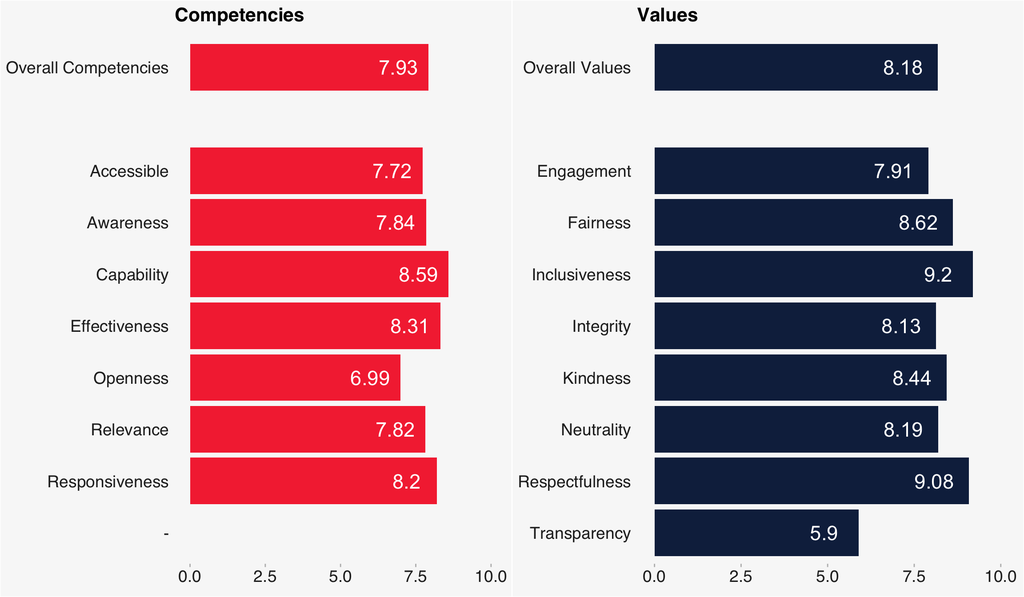

## Score by factors

Perceptions of the Colombian Red Cross are consistently positive across demographic, geographic, and engagement groups, with most competency and value scores ranging between 7 and 9 out of 10. While variations exist, the overall pattern reflects a high level of trust across the surveyed population.

*Distribution of mean scores for values and competencies per demographic questions*

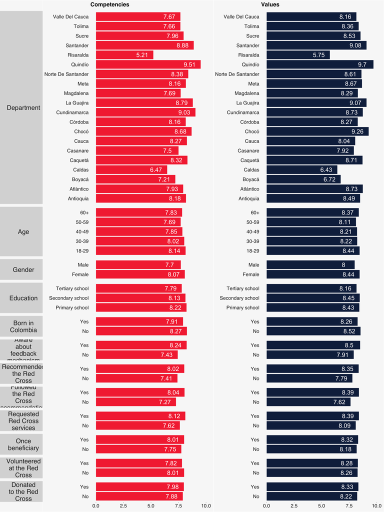

## Score by respondent profile

- Respondents with prior engagement with the Colombian Red Cross tend to report more positive perceptions than those without such experience. Former beneficiaries and volunteers score both competencies and values slightly higher than other respondents, particularly on dimensions related to effectiveness, capability, engagement, and neutrality.
- Across all groups, perceptions remain strongly positive, with overall competency scores ranging from 7.65 to 8.07 and value scores from 8.08 to 8.36. Inclusiveness, Respectfulness, and Kindness are consistently among the highest-rated dimensions, reflecting strong perceptions of how the organization interacts with communities.
- Transparency remains the lowest-rated value across all groups, scoring between 5.56 and 6.26. While still moderately positive, this suggests opportunities to strengthen communication around decision-making processes, resource allocation, and organizational accountability.

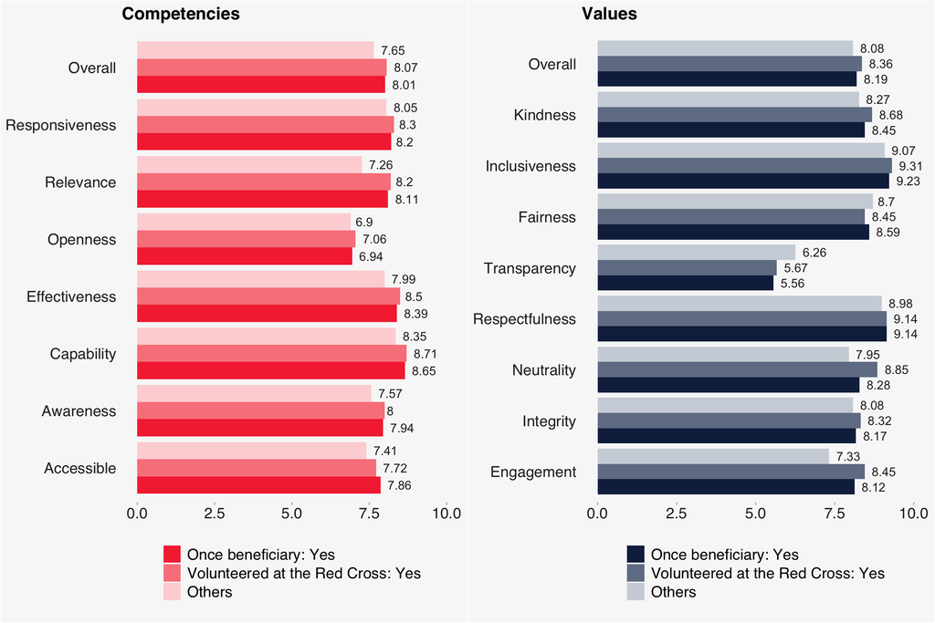

# Methods and Metrics

## Metrics

### Gender

### Age

### Geographic

### Relationship with RC

## Methods

**Scoring methodology**

To determine the score, we employ the following method:

1. Survey Structure The CTI survey includes multiple questions grouped under sub-dimensions of two main categories:
   - Competencies (e.g., reliability, effectiveness, technical proficiency)
   - Values (e.g., ethics, integrity, fairness, transparency)
2. Sub-Dimension Scoring

   Each sub-dimension comprises several survey items (questions).Respondents answer on a Likert-type scale (1 to 4 - Don’t not is excluded). For each sub-dimension:

   *Sub-dimension Score = ∑ (Weighted Response Scores) / Number of Items*

If weights are not empirically derived, equal weighting is typically applied to each item.

3. Dimension Scoring

Once all sub-dimension scores are calculated, the Competency Score and Values Score are each derived as the arithmetic mean of their respective sub-dimension scores:

- *Competency Score = ∑(Sub-dimension Scores for Competency) /𝑛*
- *Values Score = ∑(Sub-dimension Scores for Values)/𝑚*

where 𝑛 and 𝑚 are the number of sub-dimensions in each category.

4. Overall Scoring

   The final Community Trust Index score is the arithmetic mean of the Competency and Values scores:
- *CTI Score = (Competency Score + Values Score)/2*

## Weighting

**Weighting vs. unweighting**

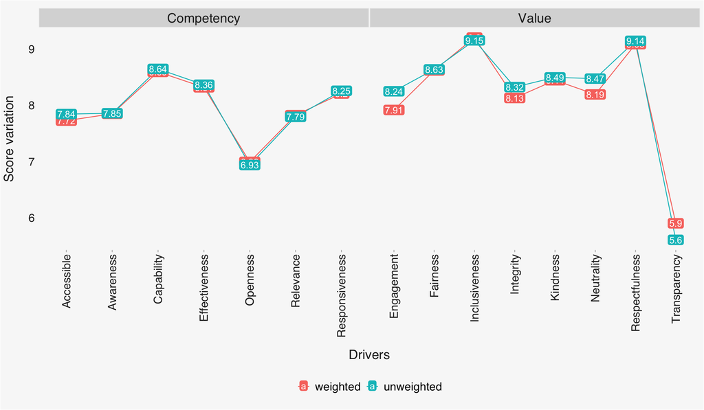

## Drivers Correlation

**Correlation matrix**

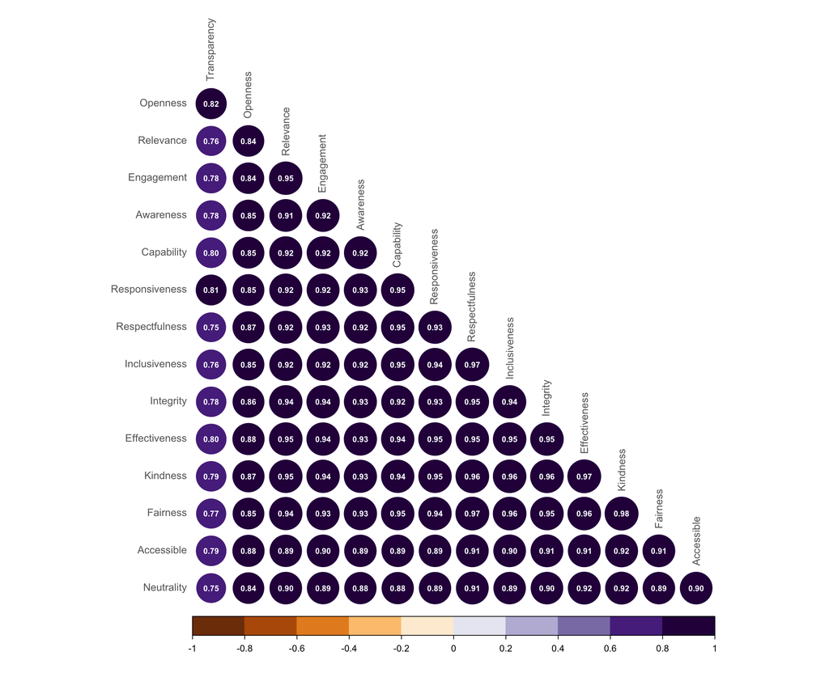

*How to read the correlation matrix:*

*1. Find the row and column*

*2. Read the number inside the circle*

- *Values range from **–1 to +1***
- *Interpretation:*

| Value | Meaning |
| --- | --- |
| 0.00 | No relationship |
| 0.10–0.30 | Weak |
| 0.30–0.50 | Mild |
| 0.50–0.70 | Moderate |
| 0.70–1.00 | Strong |
| Negative values | Variables move in opposite directions |

## Significance testing

**Significance testing**

# Download

Download Summary Excel File